# Scalar alternatives analysis

Ben Peloquin & Mike Frank

July 22, 2016

```r
rm(list=ls())
```

Packages

```r
library(purrr)
library(dplyr)
library(tidyr)
library(ggplot2)
library(rjson)
library(binom)
library(lme4)
library(lmerTest)
library(rrrsa)
source("/Users/benpeloquin/Desktop/Projects/scalar_alts/analysis/scalar_alts_analysis_helpers.R")
```

Experimental set-up notes

Note: this is not a part of pre-registration analysis

```r
## Literal listener trials
NUM_ITEMS <- 105
trials <- sample.int(n=NUM_ITEMS, size=NUM_ITEMS)

trial_meta <- function(n) {
  item <- n %% 21
  stars <- n %% 5
  c("item"=item, "stars"=stars)
}

d_trials <- data.frame(t(as.matrix(sapply(trials, trial_meta))))
d_trials <- d_trials %>%
  mutate(stars=stars + 1) %>%
  arrange(item)
```

# Stimuli

```r
## global data
NUM_ITEMS <- 21 ## number of individual target scalars (some are shared)
DOMAINS <- c("album", "book", "game", "play", "movie", "restaurant")
## scales
bad_terrible <-            c("terrible", "bad", "okay", "good", "great")
liked_loved <-             c("hated", "disliked", "tolerated", "liked", "loved")
good_excellent <-          c("terrible", "bad", "average", "good", "excellent")
memorable_unforgettable <- c("forgettable", "boring", "ordinary", "memorable", "unforgettable")
special_unique <-          c("boring", "different", "common", "special", "unique")
all_scales <- data.frame("bad_terrible"=bad_terrible,
                         "liked_loved"=liked_loved,
                         "good_excellent"=good_excellent,
                         "memorable_unforgettable"=memorable_unforgettable,
                         "special_unique"=special_unique)
weaker <- c("bad", "liked", "good", "memorable", "special")
stronger <- c("terrible", "loved", "excellent", "unforgettable", "unique")

## valence
map_word_type <- function(word) {
  hi2 <- c("great", "loved", "excellent", "unforgettable", "unique")
  hi1 <- c("good", "liked", "memorable", "special")
  mid <- c("okay", "tolerated", "average", "ordinary", "common")
  low1 <- c("bad", "disliked", "bad", "forgettable", "different")
  low2 <- c("terrible", "hated", "terrible", "boring", "boring")

  if (word %in% hi2) "hi2"
  else if (word %in% hi1) "hi1"
  else if (word %in% mid) "mid"
  else if (word %in% low1) "low1"
  else if (word %in% low2) "low2"
  else "training"
}
```

# 1) Literal Listener (L0) analysis

## Experimental set-up

Literal listener studies provide approximate literal semantic data for our target scalar items.

We’re testing 5 scales, each containing 5 items, across 6 domains (see `Stimuli` section above). Since some words are shared between scales we have 21 unique words. See `Stimuli` section above.

Data for domains is between subjects – subjects only provide responses in the context of one domain at a time.

Data for individual words is within subjects – subjects provide five ratings for each word (one judgment for each star rating 1-5 stars for a total of 5 * 21 = 105 responses for each participant).

Response is a binary `yes`/`no` response if the target word is compatible with the displayed star-rating.

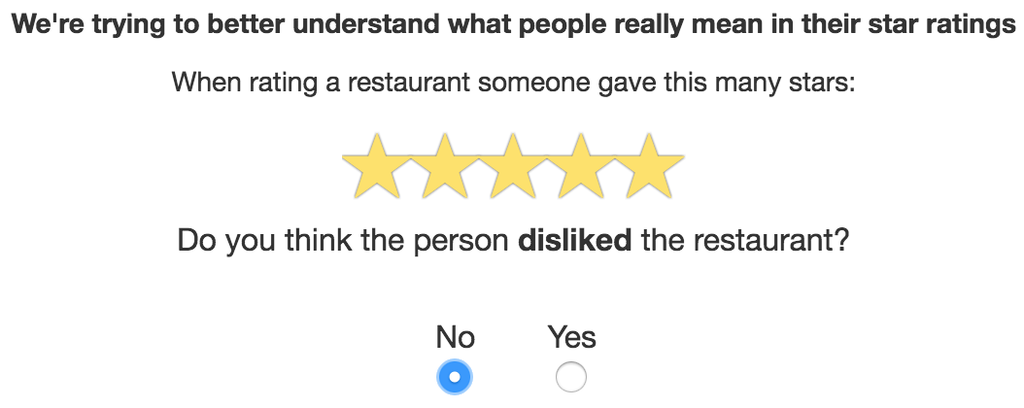

Example trial from L0 Literal listener study.

## Data pre-processing (combine domains, data-typing).

```r
d_album_L0 <- create_domain_df("album", dir_path=create_dir_path("album", "L0"), study_type="L0", filter=TRUE, verbose=TRUE)
d_book_L0 <- create_domain_df("book", dir_path=create_dir_path("book", "L0"), study_type="L0", filter=TRUE, verbose=TRUE)
d_game_L0 <- create_domain_df("game", dir_path=create_dir_path("game", "L0"), study_type="L0", filter=TRUE, verbose=TRUE)
d_movie_L0 <- create_domain_df("movie", dir_path=create_dir_path("movie", "L0"), study_type="L0", filter=TRUE, verbose=TRUE)
d_play_L0 <- create_domain_df("play", dir_path=create_dir_path("play", "L0"), study_type="L0", filter=TRUE, verbose=TRUE)
d_restaurant_L0 <- create_domain_df("restaurant",
                                 dir_path=create_dir_path("restaurant", "L0"), study_type="L0", filter=TRUE, verbose=TRUE)

d_agg_L0 <- rbind(d_album_L0, d_book_L0, d_game_L0, d_movie_L0, d_play_L0, d_restaurant_L0)
```

Non-normalized literal semantics with CI intervals

```r
## Literal semantics
d_agg_sems <- d_agg_L0 %>%
  group_by(domain, item, word_type, stars) %>%
  summarise(avg_judgment=mean(judgment),
            ci_low=binom.confint(sum(judgment), length(judgment))$lower[3],
            ci_high=binom.confint(sum(judgment), length(judgment))$upper[3]) %>%
  ungroup %>%
  mutate(domain=as.factor(domain))
```

## Primary analysis - domain level differences

### Plots by scalar pairs and domains

Plot non-normalized literal listener semantics, facet by word, color by domain.

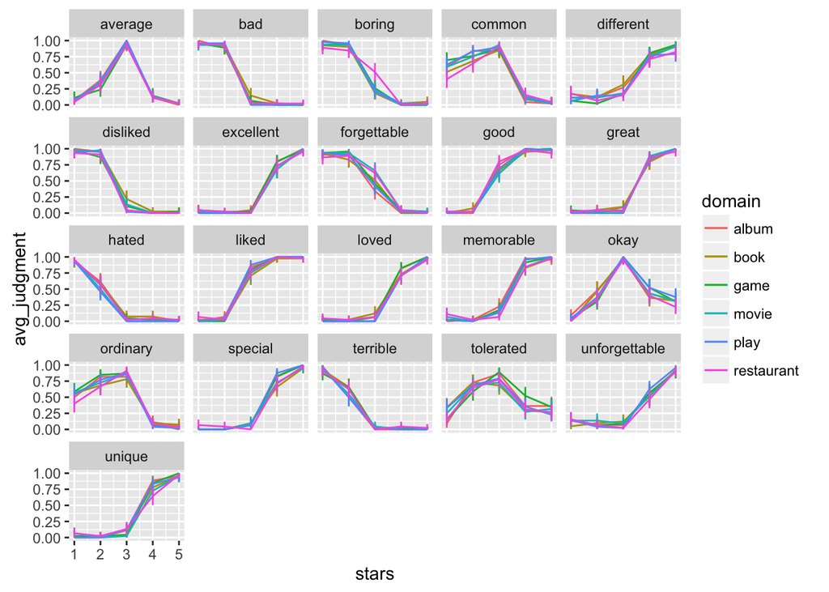

```r
ggplot(d_agg_sems, aes(x=stars, y=avg_judgment, col=domain)) +
  geom_line() +
  geom_errorbar(aes(ymax=ci_high, ymin=ci_low), width=0) +
  facet_wrap(~item)
```

Plot non-normalized literal listener semantics, facet by scale and word-valence, color by word.

```r
ggplot(d_agg_sems, aes(x=stars, y=avg_judgment, col=item)) +
  geom_line() +
  geom_errorbar(aes(ymax=ci_high, ymin=ci_low), width=0) +
  facet_grid(domain~word_type)
```

[output not shown]

Doesn’t look like there’s much differentiation in literal semantics by domain.

### Does domain predict response?

Statistical test: Logistic regression

Is `domain` a sigificant predictor of response.

Null hypothesis is there are no differences between domain (i.e. domain should not significantly predict response after controlling for `target_word`).

```r
## L0 listener data for glmer and glm
d_agg_L0_test <- d_agg_L0 %>%
  mutate(worker_id=as.factor(worker_id),
         study=as.factor(study),
         domain=as.factor(domain),
         word_type=as.factor(word_type),
         item=as.character(item))
# knitr::kable(summary(glm(judgment~item+domain+word_type, family="binomial", data=d_agg_L0_test)))
## Having convergence issues with glmer
# summary(glmer(judgment ~ item + (1|worker_id), family="binomial", data=d_agg_L0_test))
knitr::kable(summary(glm(judgment ~ item*domain + stars, family="binomial", data=d_agg_L0_test))$coef)
```

|  | Estimate | Std. Error | z value | Pr(>\|z\|) |
| --- | --- | --- | --- | --- |
| (Intercept) | -1.2205660 | 0.1484571 | -8.2216730 | 0.0000000 |
| itembad | 0.3428454 | 0.2014405 | 1.7019683 | 0.0887613 |
| itemboring | 0.4760540 | 0.2002862 | 2.3768681 | 0.0174603 |
| itemcommon | 0.6620594 | 0.1993589 | 3.3209431 | 0.0008971 |
| itemdifferent | 0.5135772 | 0.2000356 | 2.5674289 | 0.0102456 |
| itemdisliked | 0.3812452 | 0.2010650 | 1.8961293 | 0.0579429 |
| itemexcellent | 0.2453821 | 0.2025524 | 1.2114496 | 0.2257231 |
| itemforgettable | 0.5135772 | 0.2000356 | 2.5674289 | 0.0102456 |
| itemgood | 0.9749930 | 0.1995552 | 4.8858310 | 0.0000010 |
| itemgreat | 0.2846389 | 0.2020769 | 1.4085673 | 0.1589632 |
| itemhated | 0.0422791 | 0.2056291 | 0.2056084 | 0.8370968 |
| itemliked | 1.1055629 | 0.2002898 | 5.5198157 | 0.0000000 |
| itemloved | 0.2846389 | 0.2020769 | 1.4085673 | 0.1589632 |
| itemmemorable | 0.5322670 | 0.1999229 | 2.6623619 | 0.0077594 |
| itemokay | 0.6066239 | 0.1995531 | 3.0399126 | 0.0023665 |
| itemordinary | 0.6251288 | 0.1994805 | 3.1337834 | 0.0017257 |
| itemspecial | 0.2846389 | 0.2020769 | 1.4085673 | 0.1589632 |
| itemterrible | -0.0866087 | 0.2081431 | -0.4161016 | 0.6773356 |
| itemtolerated | 0.7173039 | 0.1992341 | 3.6003075 | 0.0003178 |
| itemunforgettable | 0.1656230 | 0.2036357 | 0.8133297 | 0.4160291 |
| itemunique | 0.3428454 | 0.2014405 | 1.7019683 | 0.0887613 |
| domainbook | -0.0529952 | 0.2112415 | -0.2508751 | 0.8019107 |
| domaingame | -0.1281303 | 0.2067082 | -0.6198605 | 0.5353496 |
| domainmovie | -0.0213855 | 0.2068144 | -0.1034045 | 0.9176419 |
| domainplay | -0.0053305 | 0.2021529 | -0.0263689 | 0.9789631 |
| domainrestaurant | -0.1405426 | 0.2081330 | -0.6752541 | 0.4995144 |
| stars | 0.1432525 | 0.0087464 | 16.3784486 | 0.0000000 |
| itembad:domainbook | 0.1322862 | 0.2902911 | 0.4557018 | 0.6486044 |
| itemboring:domainbook | 0.0396749 | 0.2892527 | 0.1371634 | 0.8909016 |
| itemcommon:domainbook | -0.0658772 | 0.2882216 | -0.2285645 | 0.8192074 |

[output cut: 97 more lines]

I’m having convergence issues with `glmer()` so I’m sticking with multiple logistic regression. We’re including the interaction term `item*domain` here. I’m not seeing signs of significant differences between indiviual words and domains from this summary.

## Secondary analysis – word level differences

### Plots by word and domains (line chart, facets by word, lines are literal semantics for each domain)

```r
# ggplot()
```

### Statistical test

- Logistic regression on data subset for each word

H0: domain should not predict response.

```r
# glm()
```

- Chi-square test of independence

```r
# chisq.test()
```

# 2) Pragmatic Listener (L1) analysis

## Experimental set-up

Pragmatic listener studies provide pragmatic interpretations for our target scalar items.

We’re testing 5 scales, each containing 5 items, across 6 domains (see `stimuli` section above). Since some words are shared between scales we have 21 unique words.

Data for domains is between subjects – subjects only provide responses in the context of one domain at a time.

Data for individual words is within subjects – subjects provide one rating for each word (providing 1 * 21 = 21 responses per particpant).

Response is a rating between 1-5 stars.

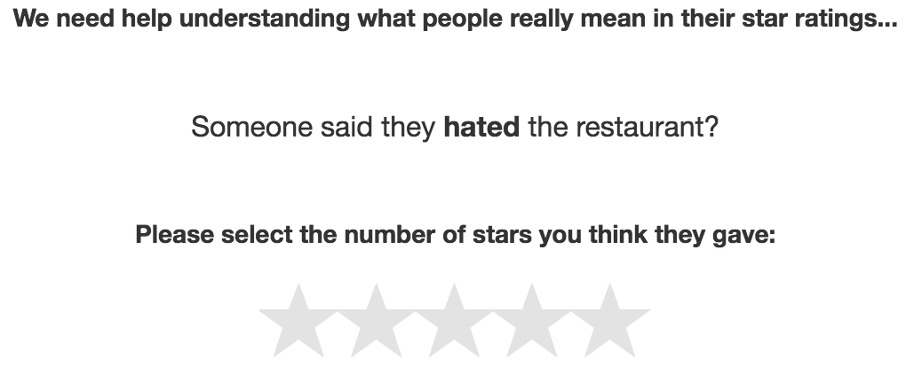

Example trial from L1 Pragmatic listener study.

## Data pre-processing (combine domains, data-typing).

```r
d_album_L1 <- create_domain_df("album", dir_path=create_dir_path("album", "L1"), study_type="L1", filter=TRUE, verbose=TRUE)
d_book_L1 <- create_domain_df("book", dir_path=create_dir_path("book", "L1"), study_type="L1", filter=TRUE, verbose=TRUE)
d_game_L1 <- create_domain_df("game", dir_path=create_dir_path("game", "L1"), study_type="L1", filter=TRUE, verbose=TRUE)
d_movie_L1 <- create_domain_df("movie", dir_path=create_dir_path("movie", "L1"), study_type="L1", filter=TRUE, verbose=TRUE)
d_play_L1 <- create_domain_df("play", dir_path=create_dir_path("play", "L1"), study_type="L1", filter=TRUE, verbose=TRUE)
d_restaurant_L1 <- create_domain_df("restaurant",
                                 dir_path=create_dir_path("restaurant", "L1"), study_type="L1", filter=TRUE, verbose=TRUE)

d_agg_L1 <- rbind(d_album_L1, d_book_L1, d_game_L1, d_movie_L1, d_play_L1, d_restaurant_L1)
```

Pragmatic judgment counts

```r
d_agg_prags <-  d_agg_L1 %>%
  group_by(domain, word_type, item, judgment) %>%
  summarise(counts=n()) %>%
  ungroup %>%
  group_by(domain, item) %>%
  mutate(total_item_counts=sum(counts)) %>%
  rowwise %>%
  mutate(proportion_counts=counts/total_item_counts)
```

Average ragins – bootstrap CI’s here…

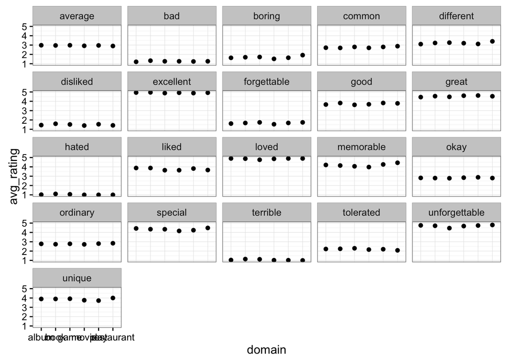

```r
d_agg_prags %>%
  mutate(judgment_times_counts=judgment*counts) %>%
  group_by(domain, item, total_item_counts) %>%
  summarise(total_weighted_counts=sum(judgment_times_counts)) %>%
  mutate(avg_rating=total_weighted_counts/total_item_counts) %>%
  ggplot(aes(x=domain, y=avg_rating)) +
    geom_point() +
    # geom_bar(stat="identity", position="dodge") +
    facet_wrap(~item) +
    theme_bw()
```

## Primary analysis – domain level differences

### Plots by scalar pairs and domains

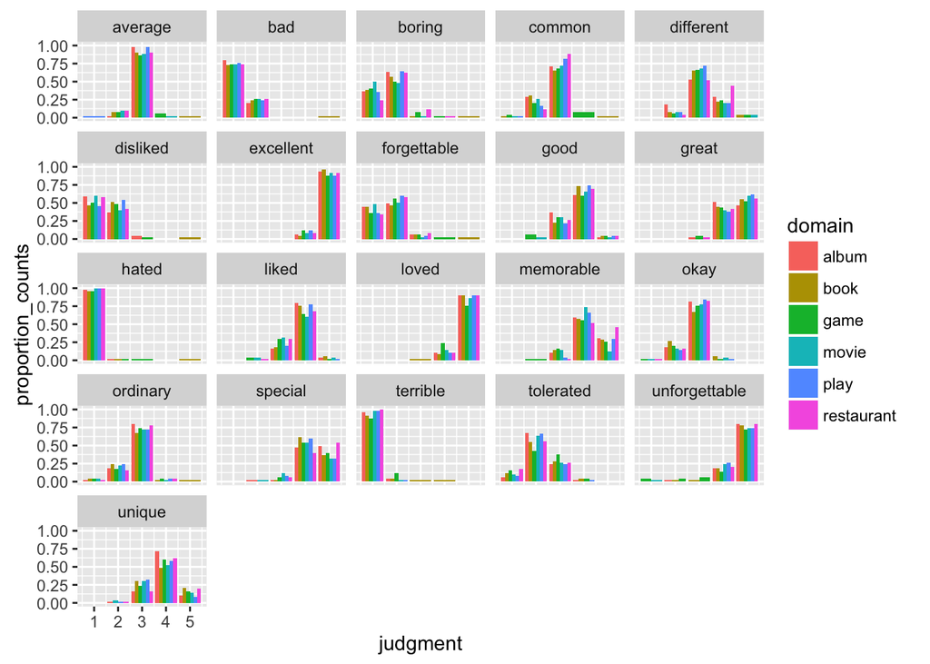

```r
ggplot(d_agg_prags, aes(x=judgment, y=proportion_counts, fill=domain)) +
    geom_bar(position="dodge", stat="identity") +
    facet_wrap(~item)
```

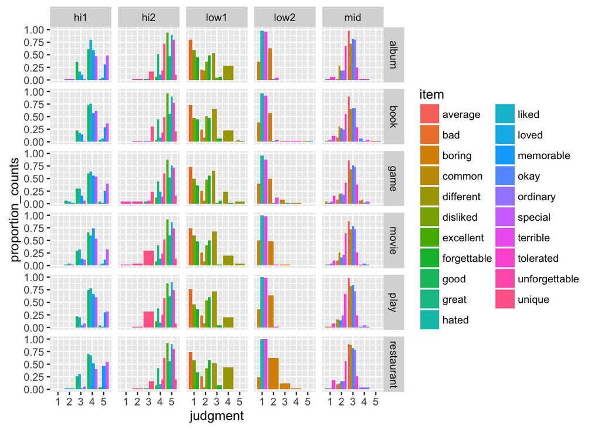

```r
ggplot(d_agg_prags, aes(x=judgment, y=proportion_counts, fill=item)) +
    geom_bar(position="dodge", stat="identity") +
    facet_grid(domain~word_type)
```

### Does domain predict response?

Statistical test: Multiple regression

Is `domain` a sigificant predictor of response.

Null hypothesis is there are no differences between domain (i.e. domain should not significantly predict response).

```r
knitr::kable(summary(lmer(judgment~domain + (1|item) + (1|worker_id), data=d_agg_L1))$coef)
```

|  | Estimate | Std. Error | df | t value | Pr(>\|t\|) |
| --- | --- | --- | --- | --- | --- |
| (Intercept) | 2.9974061 | 0.2889332 | 20.47817 | 10.3740452 | 0.0000000 |
| domainbook | 0.0492527 | 0.0414562 | 570.50061 | 1.1880663 | 0.2353016 |
| domaingame | 0.0158568 | 0.0427391 | 468.52572 | 0.3710143 | 0.7107946 |
| domainmovie | -0.0002122 | 0.0426812 | 486.73019 | -0.0049712 | 0.9960356 |
| domainplay | 0.0744118 | 0.0419638 | 525.42216 | 1.7732365 | 0.0767688 |
| domainrestaurant | 0.0868406 | 0.0412994 | 563.82082 | 2.1027098 | 0.0359338 |

```r
knitr::kable(summary(lmer(judgment~domain*item + (1|worker_id), data=d_agg_L1))$coef)
```

|  | Estimate | Std. Error | df | t value | Pr(>\|t\|) |
| --- | --- | --- | --- | --- | --- |
| (Intercept) | 2.9447109 | 0.0743117 | 5169.006 | 39.6264586 | 0.0000000 |
| domainbook | -0.0040690 | 0.1042741 | 5604.379 | -0.0390219 | 0.9688743 |
| domaingame | 0.0256714 | 0.1043561 | 5290.440 | 0.2459979 | 0.8056934 |
| domainmovie | -0.0064397 | 0.1043316 | 5338.905 | -0.0617234 | 0.9507854 |
| domainplay | 0.0453990 | 0.1040390 | 5477.009 | 0.4363646 | 0.6625894 |
| domainrestaurant | -0.0442826 | 0.1037719 | 5590.708 | -0.4267302 | 0.6695923 |
| itembad | -1.7755102 | 0.0980599 | 5850.640 | -18.1063931 | 0.0000000 |
| itemboring | -1.3469388 | 0.0980599 | 5850.640 | -13.7358844 | 0.0000000 |
| itemcommon | -0.2653061 | 0.0980599 | 5850.640 | -2.7055530 | 0.0068388 |
| itemdifferent | 0.1224490 | 0.0980599 | 5850.640 | 1.2487168 | 0.2118187 |
| itemdisliked | -1.5306122 | 0.0980599 | 5850.640 | -15.6089595 | 0.0000000 |
| itemexcellent | 1.9591837 | 0.0980599 | 5850.640 | 19.9794682 | 0.0000000 |
| itemforgettable | -1.3673469 | 0.0980599 | 5850.640 | -13.9440039 | 0.0000000 |
| itemgood | 0.6734694 | 0.0980599 | 5850.640 | 6.8679422 | 0.0000000 |
| itemgreat | 1.4693878 | 0.0980599 | 5850.640 | 14.9846012 | 0.0000000 |
| itemhated | -1.9591837 | 0.0980599 | 5850.640 | -19.9794682 | 0.0000000 |
| itemliked | 0.8979592 | 0.0980599 | 5850.640 | 9.1572563 | 0.0000000 |
| itemloved | 1.9183673 | 0.0980599 | 5850.640 | 19.5632293 | 0.0000000 |
| itemmemorable | 1.2244898 | 0.0980599 | 5850.640 | 12.4871676 | 0.0000000 |
| itemokay | -0.1632653 | 0.0980599 | 5850.640 | -1.6649557 | 0.0959751 |
| itemordinary | -0.2040816 | 0.0980599 | 5850.640 | -2.0811946 | 0.0374595 |
| itemspecial | 1.4489796 | 0.0980599 | 5850.640 | 14.7764817 | 0.0000000 |
| itemterrible | -1.9387755 | 0.0980599 | 5850.640 | -19.7713487 | 0.0000000 |
| itemtolerated | -0.7551020 | 0.0980599 | 5850.640 | -7.7004200 | 0.0000000 |
| itemunforgettable | 1.7755102 | 0.0980599 | 5850.640 | 18.1063931 | 0.0000000 |
| itemunique | 0.9183673 | 0.0980599 | 5850.640 | 9.3653757 | 0.0000000 |
| domainbook:itembad | 0.1428571 | 0.1386776 | 5850.640 | 1.0301388 | 0.3029874 |
| domaingame:itembad | 0.0555102 | 0.1379824 | 5850.640 | 0.4022990 | 0.6874787 |
| domainmovie:itembad | 0.1155102 | 0.1379824 | 5850.640 | 0.8371370 | 0.4025498 |
| domainplay:itembad | 0.0555102 | 0.1379824 | 5850.640 | 0.4022990 | 0.6874787 |

[output cut: 96 more lines]

## Secondary analysis – word level differences

### Plots by word and domains (line chart, facets by word, lines are pragmatic judgments for each domain)

```r
# ggplot()
```

### Statistical tests

Null hypothesis is scalar word pragmatic judgment distributions should not differ by domain.

- Multiple regression on data subset

Domain should not predict response when controlling for `target_word`

```r
# glm()
```

We don’t expect to see any statistical differences.

```r
# chisq.test()
```

# 3) RSA comparison with human judgments

## RSA helpers

Combine L0 and L1 data. Prepare for use with `rrrsa`.

```r
## rsa_read_df()
## ------------
## Write a data frame that is read to run through rsa.runDf
##
rsa_read_df <- function(d_L0, d_L1) {

  ## Normalize L0
  normalize_semantics <- function(d) {
    norm_vec(d$avg_judgment)
  }
  pattern <- "V([1-5])"
  d_L0_sems <- plyr::ddply(.data=d_L0, .variables=c("domain", "word_type", "item"), .fun=normalize_semantics) %>%
    gather(stars, sems, -c(domain, word_type, item)) %>%
    arrange(domain, item, stars, word_type) %>%
    rowwise %>%
    mutate(stars=as.numeric(gsub(pattern, "\\1", stars)))

  ## Combine L0 and L1 data
  d_agg_L0_merge <- d_L0_sems
  d_agg_L1_merge <- d_L1 %>%
    mutate(stars=judgment) %>%
    select(domain, word_type, item, stars, counts)

  ## Joined data (L1 not normalized)
  d_agg_join <- plyr::join(d_agg_L0_merge, d_agg_L1_merge, by=c("domain", "word_type", "item", "stars"))
  d_agg_join[is.na(d_agg_join)] <- 0

  ## Normalize L1
  normalize_pragmatics <- function(d) {
    norm_vec(d$counts)
  }
  pattern <- "V([1-5])"
  normed_prags <- plyr::ddply(.data=d_agg_join, .variables=c("domain", "word_type", "item"), .fun=normalize_pragmatics) %>%
    gather(key=stars, value=prags, c(V1, V2, V3, V4, V5)) %>%
    rowwise %>%
    mutate(stars=as.numeric(gsub(pattern, "\\1", stars))) %>%
    arrange(domain, item, stars)

  ## Combined normalized semantics and pragmatics df
  d_agg_final <- plyr::join(d_agg_join, normed_prags, by=c("domain", "word_type", "item", "stars"))

  ## Data in wide format
  sems_wide <- d_agg_final %>% select(domain, word_type, item, stars, sems) %>%
    spread(stars, sems)
  prags_wide <- d_agg_final %>% select(domain, word_type, item, stars, prags) %>%
    spread(stars, prags)

  ## Data holds for separate semantics and pragmatics
  sems_scales_df <- data.frame(domain=c(),
                            item=c(),
                            scale=c(),
                            "1"=c(),
                            "2"=c(),
                            "3"=c(),
                            "4"=c(),
                            "5"=c())
  prags_scales_df <- data.frame(domain=c(),
                            item=c(),
                            scale=c(),
                            "1"=c(),
                            "2"=c(),
                            "3"=c(),
                            "4"=c(),
                            "5"=c())
  ## Populate data holds
  for (domain in DOMAINS) {
    for (scale in names(all_scales)) {
      for (item in all_scales[[scale]]) {
        # print("item:")
        # print(item)
        # print("----------------------")
        curr_sems_row <- sems_wide[which(sems_wide$item==item & sems_wide$domain==domain),] %>%
          mutate(scale=scale)
        curr_prags_row <- prags_wide[which(prags_wide$item==item & prags_wide$domain==domain),] %>%
          mutate(scale=scale)
        sems_scales_df <- rbind(sems_scales_df, curr_sems_row)
        prags_scales_df <- rbind(prags_scales_df, curr_prags_row)
      }
    }
  }
  sems_scales_df <- sems_scales_df %>%
    arrange(domain, scale, word_type, item) %>%
    gather(stars, sems, -c(domain, scale, word_type, item))
  prags_scales_df <- prags_scales_df %>%
    arrange(domain, scale, word_type, item) %>%
    gather(stars, prags, -c(domain, scale, word_type, item))

  ## Quick check
  nrow(sems_scales_df) == nrow(prags_scales_df)

  sems_scales_df[1:10,]
  prags_scales_df[1:10,]

  d_rsa_df <- dplyr::full_join(sems_scales_df, prags_scales_df)

  d_rsa_df
}
```

Get model indices

```r
## get_compare_indices()
## ----------------------
## map word valence labels by model type
##
get_compare_indices <- function(d, model=NA) {

  if (model=="2") {
    indices <- which((d$scale=="bad_terrible" &
                        (d$word_type=="low1" |  d$word_type=="low2")) |
                       (d$scale!="bad_terrible" &
                          (d$word_type=="hi1" |  d$word_type=="hi2")))
  } else if (model=="3") {
    indices <- which((d$scale=="bad_terrible" &
                        (d$word_type=="low1" |  d$word_type=="low2" | d$word_type=="hi1")) |
                       (d$scale!="bad_terrible" &
                          (d$word_type=="hi1" |  d$word_type=="hi2" | d$word_type=="low1")))
  } else if (model=="4") {
    indices <- which((d$scale=="bad_terrible" &
                        (d$word_type=="low1" |  d$word_type=="low2" | d$word_type=="hi1" | d$word_type=="hi2")) |
                       (d$scale!="bad_terrible" &
                          (d$word_type=="hi1" |  d$word_type=="hi2" | d$word_type=="low1" | d$word_type=="low2")))

  } else if (model=="5") {
    indices <- seq(nrow(d))
  } else error("Please specify model; one of '2', '3', '4', or '5'")

  indices
}
```

Combined df with sems and prags

```r
d_joined_m <- rsa_read_df(d_agg_sems, d_agg_prags)
```

Individual models

```r
two_alt_m <- d_joined_m[get_compare_indices(d_joined_m, model="2"), ]
three_alt_m <- d_joined_m[get_compare_indices(d_joined_m, model="3"), ]
four_alt_m <- d_joined_m[get_compare_indices(d_joined_m, model="4"), ]
five_alt_m <- d_joined_m[get_compare_indices(d_joined_m, model="5"), ]
```

– Using L0 literal semantics as input to RSA how well can we fit the L1 pragmatic listener judgments varying the alternative sets available to the model?

## Basic RSA

### Experiment 1: Tune depth alpha for each model aggregating over `scale` and `domain`

Tune models aggregating over `domain`

```r
ALPHAS <- seq(0, 6, by=0.1)
DEPTHS <- seq(0, 4)
MODELS <- as.character(seq(2, 5))

plot_tuning_curves <- function(d) {
  ggplot(d, aes(x=alpha, y=r, col=as.factor(depth))) +
    geom_line()
}
```

```r
## tune_alpha_depth()
## ------------
## tune alphas for model against taregt indices
##
tune_alpha_depth_over_domain_scale <- function(d_model,
                             alphas=seq(1, 4, by=0.1),
                             depths=seq(1,3)) {

  cors <- data.frame(r=c(), alpha=c(), depth=c())
  for (alpha in alphas) {
    for (depth in depths) {

      ## Run on each alpha/depth
      out <- d_model %>%
        split(list(.$domain, .$scale)) %>%
        map_df(~rsa.runDf(
          data=.x,
          quantityVarName="stars",
          semanticsVarName="sems",
          itemVarName="item",
          depth=depth,
          alpha=alpha))

      tune_indices <- get_compare_indices(out, model="2")
      out_check <- out[tune_indices,]
      curr_cor <- cor(out_check$preds, out_check$prags)
      cors <- rbind(cors, data.frame(r=curr_cor, alpha=alpha, depth=depth))
    }
  }
  cors
}
```

Reproduce original tests (assume one level of recursion and tune alpha)

```r
m_test1 <- read.csv("/Users/benpeloquin/Desktop/Projects/scalar_alts/analysis/cache/m_test1.csv")
```

M2

```r
if (!("m_test1" %in% ls(envir=.GlobalEnv))) {
  two_alt_res <- tune_alpha_depth_over_domain_scale(two_alt_m, alphas=ALPHAS, depths=1)
  best_two_alpha <- two_alt_res[which.max(two_alt_res$r), ]
  plot_tuning_curves(two_alt_res)
}
```

M3

```r
if (!("m_test1" %in% ls(envir=.GlobalEnv))) {
  three_alt_res <- tune_alpha_depth_over_domain_scale(three_alt_m, alphas=ALPHAS, depths=1)
  best_three_alpha <- three_alt_res[which.max(three_alt_res$r), ]
  plot_tuning_curves(three_alt_res)
}
```

M4

```r
if (!("m_test1" %in% ls(envir=.GlobalEnv))) {
  four_alt_res <- tune_alpha_depth_over_domain_scale(four_alt_m, alphas=ALPHAS, depths=1)
  best_four_alpha <- four_alt_res[which.max(four_alt_res$r), ]
  plot_tuning_curves(four_alt_res)
}
```

M5

```r
if (!("m_test1" %in% ls(envir=.GlobalEnv))) {
  five_alt_res <- tune_alpha_depth_over_domain_scale(five_alt_m, alphas=ALPHAS, depths=1)
  best_five_alpha <- five_alt_res[which.max(five_alt_res$r), ]
  plot_tuning_curves(five_alt_res)
}
```

Compare tuning curves

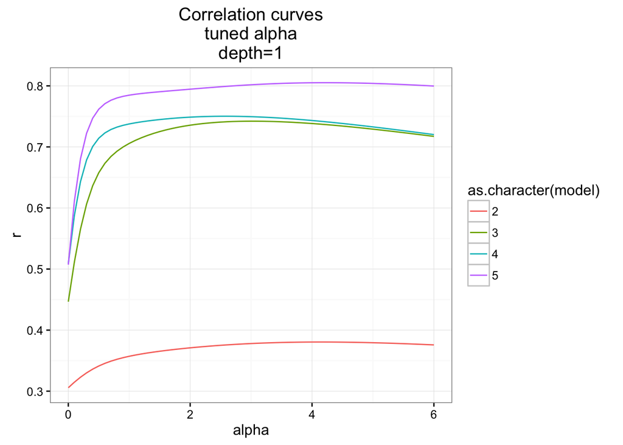

```r
curves <- read.csv("/Users/benpeloquin/Desktop/Projects/scalar_alts/analysis/cache/curves.csv")
if (!("curves" %in% ls(envir=.GlobalEnv))) {
  curves <- rbind(two_alt_res %>% mutate(model="2"),
                 three_alt_res %>% mutate(model="3"),
                 four_alt_res %>% mutate(model="4"),
                 five_alt_res %>% mutate(model="5"))
  write.csv(curves, "/Users/benpeloquin/Desktop/Projects/scalar_alts/analysis/cache/curves.csv")
}
curves %>%
  ggplot(aes(x=alpha, y=r, col=as.character(model))) +
    geom_line() +
    ggtitle("Correlation curves\ntuned alpha\ndepth=1") +
    theme_bw()
```

With a single recursion (depth=1) and tuning `alpha` we see substantial improvement in model fit with the inclusion of more alts. This is consistent with findings from our original study.

```r
curves %>%
  group_by(model) %>%
  summarise(best_r=max(r),
            best_alpha=alpha[which.max(r)]) %>%
  knitr::kable()
```

| model | best_r | best_alpha |
| --- | --- | --- |
| 2 | 0.3804885 | 4.1 |
| 3 | 0.7421536 | 3.0 |
| 4 | 0.7502283 | 2.6 |
| 5 | 0.8051623 | 4.2 |

Our best correlation in each case is lower than in our first study. We are aggregating over both `domain` and `scale`, however.

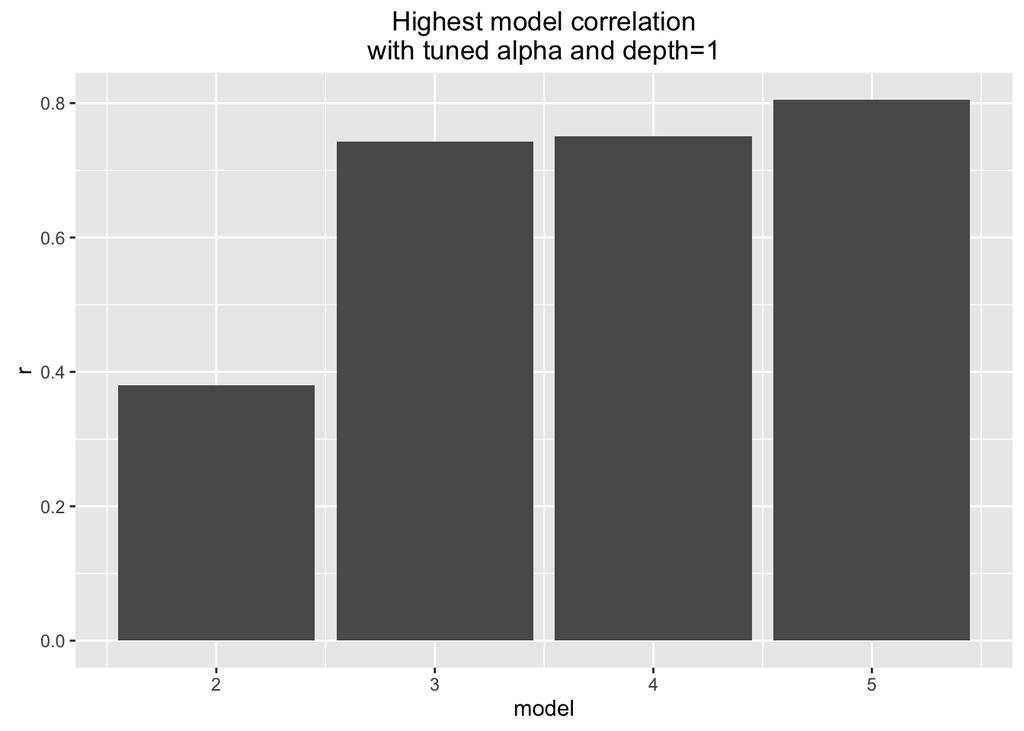

```r
if (!("m_test1" %in% ls(envir=.GlobalEnv))) {
  m_test1 <- rbind(best_two_alpha %>% mutate(model="2"),
                   best_three_alpha %>% mutate(model="3"),
                   best_four_alpha %>% mutate(model="4"),
                   best_five_alpha %>% mutate(model="5"))
  write.csv(m_test1, "/Users/benpeloquin/Desktop/Projects/scalar_alts/analysis/cache/m_test1.csv")
}

ggplot(m_test1, aes(x=model, y=r)) +
  geom_bar(stat="identity", position="dodge") +
  ggtitle("Highest model correlation\nwith tuned alpha and depth=1")
```

In this case we see substantial improvment in model fit when we include a negative valence alt…

Now tune both depth an alpha aggregating over scale and domain.

```r
m_test1b <- read.csv("/Users/benpeloquin/Desktop/Projects/scalar_alts/analysis/cache/m_test1b.csv")
if (!("m_test1b" %in% ls(envir=.GlobalEnv))) {
  two_alt_res <- tune_alpha_depth_over_domain_scale(two_alt_m, alphas=ALPHAS, depths=DEPTHS)
  three_alt_res <- tune_alpha_depth_over_domain_scale(three_alt_m, alphas=ALPHAS, depths=DEPTHS)
  four_alt_res <- tune_alpha_depth_over_domain_scale(four_alt_m, alphas=ALPHAS, depths=DEPTHS)
  five_alt_res <- tune_alpha_depth_over_domain_scale(five_alt_m, alphas=ALPHAS, depths=DEPTHS)
  m_test1b <- rbind(two_alt_res %>% mutate(model="2"),
                    three_alt_res %>% mutate(model="3"),
                    four_alt_res %>% mutate(model="4"),
                    five_alt_res %>% mutate(model="5"))
  write.csv(m_test1b, "/Users/benpeloquin/Desktop/Projects/scalar_alts/analysis/cache/m_test1b.csv")
}

m_test1b %>%
  group_by(model) %>%
  mutate(L0_r=r[which(depth==0 & alpha==0)]) %>%
  group_by(model, L0_r) %>%
  summarise(best_r=max(r),
            best_alpha=alpha[which.max(r)],
            best_depth=depth[which.max(r)]) %>%
  mutate(diff=best_r-L0_r) %>%
  knitr::kable()
```

| model | L0_r | best_r | best_alpha | best_depth | diff |
| --- | --- | --- | --- | --- | --- |
| 2 | 0.7831638 | 0.7831638 | 0.0 | 0 | 0.0000000 |
| 3 | 0.7831638 | 0.7831638 | 0.0 | 0 | 0.0000000 |
| 4 | 0.7831638 | 0.7831638 | 0.0 | 0 | 0.0000000 |
| 5 | 0.7831638 | 0.8279150 | 1.6 | 4 | 0.0447512 |

This is interesting - aggregating over scale and domain, our 2-, 3- and 4-alt listeners would be more effective (accurate) by avoiding inference and simply considering the literal semantics. Only once we get to 5-alts does RSA provide any benefits at they’re not too much.

### Experiment 2: Tune depth alpha for each `model` and `scale` aggregating over `domain`

Check for cached data…

```r
m_test2 <- read.csv("/Users/benpeloquin/Desktop/Projects/scalar_alts/analysis/cache/m_test2.csv")
```

```r
tune_alpha_depth_over_domain <- function(d_model,
                                         alphas=seq(1, 4, by=0.1),
                                         depths=seq(1,3)) {

  cors <- data.frame(r=c(), scale=c(), alpha=c(), depth=c())
  for (curr_scale in names(all_scales)) {
    for (alpha in alphas) {
      for (depth in depths) {
        ## Run on each alpha/depth
        out <- d_model %>%
          filter(scale==curr_scale) %>%
          split(list(.$domain)) %>%
          map_df(~rsa.runDf(
            data=.x,
            quantityVarName="stars",
            semanticsVarName="sems",
            itemVarName="item",
            depth=depth,
            alpha=alpha))

        tune_indices <- get_compare_indices(out, model="2")
        out_check <- out[tune_indices,]
        curr_cor <- cor(out_check$preds, out_check$prags)
        cors <- rbind(cors, data.frame(r=curr_cor, scale=curr_scale, alpha=alpha, depth=depth))
      }
    }
  }

  cors
}
```

M2

```r
if (!("m_test2" %in% ls(envir=.GlobalEnv))) {
  two_alt_res <- tune_alpha_depth_over_domain(two_alt_m, alphas=ALPHAS, depths=DEPTHS)
  best_2 <- two_alt_res %>%
    group_by(scale) %>%
    mutate(L0_r=r[which(depth==0 & alpha==0)]) %>%
    group_by(scale, L0_r) %>%
    summarise(best_r=max(r),
              best_alpha=alpha[which.max(r)],
              best_depth=depth[which.max(r)]) %>%
    mutate(r_delta=best_r-L0_r)
}
```

M3

```r
if (!("m_test2" %in% ls(envir=.GlobalEnv))) {
  three_alt_res <- tune_alpha_depth_over_domain(three_alt_m, alphas=ALPHAS, depths=DEPTHS)
  best_3 <- three_alt_res %>%
    group_by(scale) %>%
    mutate(L0_r=r[which(depth==0 & alpha==0)]) %>%
    group_by(scale, L0_r) %>%
    summarise(best_r=max(r),
              best_alpha=alpha[which.max(r)],
              best_depth=depth[which.max(r)]) %>%
    mutate(r_delta=best_r-L0_r)
}
```

M4

```r
if (!("m_test2" %in% ls(envir=.GlobalEnv))) {
  four_alt_res <- tune_alpha_depth_over_domain(four_alt_m, alphas=ALPHAS, depths=DEPTHS)
  best_4 <- four_alt_res %>%
    group_by(scale) %>%
    mutate(L0_r=r[which(depth==0 & alpha==0)]) %>%
    group_by(scale, L0_r) %>%
    summarise(best_r=max(r),
              best_alpha=alpha[which.max(r)],
              best_depth=depth[which.max(r)]) %>%
    mutate(r_delta=best_r-L0_r)
}
```

M5

```r
if (!("m_test2" %in% ls(envir=.GlobalEnv))) {
  five_alt_res <- tune_alpha_depth_over_domain(five_alt_m, alphas=ALPHAS, depths=DEPTHS)
  best_5 <- five_alt_res %>%
    group_by(scale) %>%
    mutate(L0_r=r[which(depth==0 & alpha==0)]) %>%
    group_by(scale, L0_r) %>%
    summarise(best_r=max(r),
              best_alpha=alpha[which.max(r)],
              best_depth=depth[which.max(r)]) %>%
    mutate(r_delta=best_r-L0_r)
}
```

Taking a look at tuning together…

```r
if (!("m_test2" %in% ls(envir=.GlobalEnv))) {
  m_test2 <- rbind(best_2 %>% mutate(model="2"),
                 best_3 %>% mutate(model="3"),
                 best_4 %>% mutate(model="4"),
                 best_5 %>% mutate(model="5"))
  write.csv(m_test2, "/Users/benpeloquin/Desktop/Projects/scalar_alts/analysis/cache/m_test2.csv")
}

m_test2 %>%
  group_by(model) %>%
  summarise(num_runs=n(),
            num_run_recurse=sum(best_depth > 0),
            avg_alhpa=mean(best_alpha),
            avg_r_delta=mean(best_r-L0_r)) %>%
  knitr::kable()
```

| model | num_runs | num_run_recurse | avg_alhpa | avg_r_delta |
| --- | --- | --- | --- | --- |
| 2 | 30 | 1 | 0.080000 | 0.0031990 |
| 3 | 30 | 10 | 1.146667 | 0.0353783 |
| 4 | 30 | 13 | 1.363333 | 0.0390968 |
| 5 | 30 | 26 | 2.510000 | 0.1257322 |

```r
# ggplot(m_test2, aes(x=scale, y=best_r, fill=model)) +
#   geom_bar(stat="identity", position="dodge") +
#   theme(axis.text.x=element_text(angle=45, hjust=1))
```

Here I’m showing the total number of times that the model needed to recurse at least once with `num_run_recurse` (out of `num_runs`) as well as the average `alpha` level for each model. So out of 30 runs, 26 in the 5-model case required recursion with an average overall alpha level. This supports the (emerging story), it really only makes sense to reason about a speaker if you have alternatives available. Does this start to fit into a developmental story (Rose’s study)?

### Experiment 3: Tune depth alpha for each `model`, `scale` and `domain`

```r
tune_alpha_depth <- function(d_model,
                             alphas=seq(1, 4, by=0.1),
                             depths=seq(1,3)) {

  cors <- data.frame(r=c(), scale=c(), domain=c(), alpha=c(), depth=c())

  for (curr_domain in DOMAINS) {
    for (curr_scale in names(all_scales)) {
      for (alpha in alphas) {
        for (depth in depths) {
          ## Run on each alpha/depth
          curr_d <- d_model %>%
            filter(scale==curr_scale, domain==curr_domain)
          ## No need to use map_df here
          out <- rsa.runDf(data=curr_d,
                    quantityVarName="stars",
                    semanticsVarName="sems",
                    itemVarName="item",
                    depth=depth,
                    alpha=alpha)
          tune_indices <- get_compare_indices(out, model="2")
          out_check <- out[tune_indices,]
          ## Check if RSA predicts uniform probability across responses (then correlation is 0)
          curr_cor <- ifelse(sd(out_check$preds) != 0, cor(out_check$preds, out_check$prags), 0)
          cors <- rbind(cors, data.frame(r=curr_cor, scale=curr_scale, domain=curr_domain, alpha=alpha, depth=depth))
        }
      }
    }
  }
  cors
}
```

Check for cached data…

```r
m_test3 <- read.csv("/Users/benpeloquin/Desktop/Projects/scalar_alts/analysis/cache/m_test3.csv")
```

M2

```r
if (!("m_test3" %in% ls(envir = .GlobalEnv))) {
  two_alt_res <- tune_alpha_depth(two_alt_m, alphas=ALPHAS, depths=DEPTHS)
  best_2 <- two_alt_res %>%
    group_by(domain, scale) %>%
    mutate(L0_r=r[which(depth==0 & alpha==0)]) %>%
    group_by(domain, scale, L0_r) %>%
    summarise(best_r=max(r),
              best_alpha=alpha[which.max(r)],
              best_depth=depth[which.max(r)])
}
```

M3

```r
if (!("m_test3" %in% ls(envir = .GlobalEnv))) {
  three_alt_res <- tune_alpha_depth(three_alt_m, alphas=ALPHAS, depths=DEPTHS)
  best_3 <- three_alt_res %>%
    group_by(domain, scale) %>%
    mutate(L0_r=r[which(depth==0 & alpha==0)]) %>%
    group_by(domain, scale, L0_r) %>%
    summarise(best_r=max(r),
              best_alpha=alpha[which.max(r)],
              best_depth=depth[which.max(r)])

}
```

M4

```r
if (!("m_test3" %in% ls(envir = .GlobalEnv))) {
  four_alt_res <- tune_alpha_depth(four_alt_m, alphas=ALPHAS, depths=DEPTHS)
  best_4 <- four_alt_res %>%
    group_by(domain, scale) %>%
    mutate(L0_r=r[which(depth==0 & alpha==0)]) %>%
    group_by(domain, scale, L0_r) %>%
    summarise(best_r=max(r),
              best_alpha=alpha[which.max(r)],
              best_depth=depth[which.max(r)])
}
```

M5

```r
if (!("m_test3" %in% ls(envir = .GlobalEnv))) {
  five_alt_res <- tune_alpha_depth(five_alt_m, alphas=ALPHAS, depths=DEPTHS)
  best_5 <- five_alt_res %>%
    group_by(domain, scale) %>%
    mutate(L0_r=r[which(depth==0 & alpha==0)]) %>%
    group_by(domain, scale, L0_r) %>%
    summarise(best_r=max(r),
              best_alpha=alpha[which.max(r)],
              best_depth=depth[which.max(r)])
}
```

Summary results

```r
if (!("m_test3" %in% ls(envir = .GlobalEnv))) {
  m_test3 <- rbind(best_2 %>% mutate(model="2"),
                   best_3 %>% mutate(model="3"),
                   best_4 %>% mutate(model="4"),
                   best_5 %>% mutate(model="5"))
  write.csv(m_test3, "/Users/benpeloquin/Desktop/Projects/scalar_alts/analysis/cache/m_test3.csv")
}

m_test3 %>%
  group_by(model) %>%
  summarise(num_run_recurse=sum(best_depth > 0),
            num_comparisons=n(),
            avg_best_r=mean(best_r),
            avg_L0_r=mean(L0_r),
            avg_r_delta=mean(best_r-L0_r)) %>%
  knitr::kable()
```

| model | num_run_recurse | num_comparisons | avg_best_r | avg_L0_r | avg_r_delta |
| --- | --- | --- | --- | --- | --- |
| 2 | 1 | 30 | 0.7943178 | 0.7911188 | 0.0031990 |
| 3 | 10 | 30 | 0.8264971 | 0.7911188 | 0.0353783 |
| 4 | 13 | 30 | 0.8302156 | 0.7911188 | 0.0390968 |
| 5 | 26 | 30 | 0.9168510 | 0.7911188 | 0.1257322 |

RSA runs with best parameter settings

```r
d_best_models <- data.frame(domain=c(),
                            word_type=c(),
                            item=c(),
                            scale=c(),
                            stars=c(),
                            sems=c(),
                            prags=c(),
                            preds=c(),
                            alpha=c(),
                            depth=c(),
                            model=c())

for (i in 1:nrow(m_test3)) {
  curr_domain <- m_test3[i, ]$domain
  curr_scale <- m_test3[i, ]$scale
  curr_alpha <- m_test3[i, ]$best_alpha
  curr_depth <- m_test3[i, ]$best_depth
  curr_model_num <- m_test3[i, ]$model

  curr_d <- d_joined_m %>%
    filter(domain==curr_domain,
           scale==curr_scale)
  curr_model_indices <- get_compare_indices(curr_d, as.character(curr_model_num))
  curr_model_d <- curr_d[curr_model_indices, ]

  curr_out <- rsa.runDf(curr_model_d,
                        quantityVarName="stars",
                        semanticsVarName="sems",
                        itemVarName="item",
                        alpha=curr_alpha,
                        depth=curr_depth) %>%
    mutate(alpha=curr_alpha,
           depth=curr_depth,
           model=curr_model_num)

  d_best_models <- rbind(d_best_models, curr_out)
}
```

Best model fit scatter plots

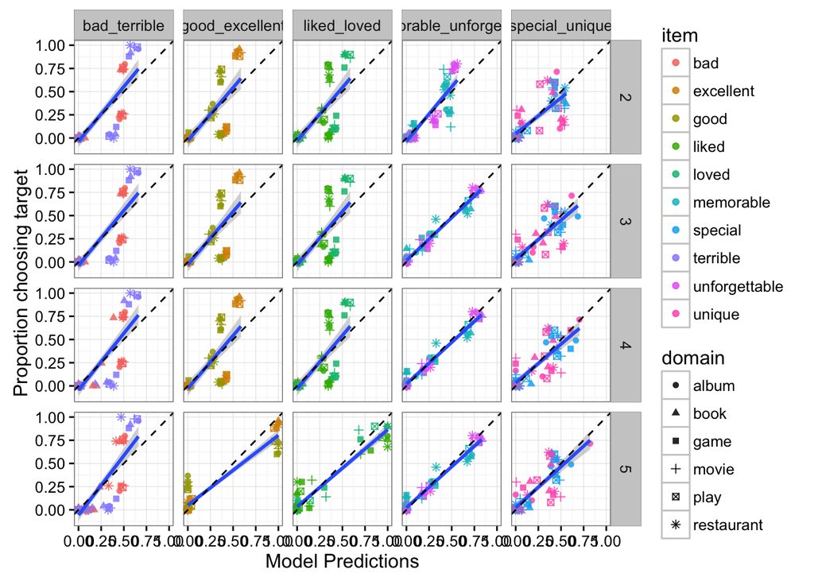

```r
compare_indices <- get_compare_indices(d_best_models, model="2")
d_best_models[compare_indices, ] %>%
  ggplot(aes(x=preds, y=prags)) +
    xlab("Model Predictions") +
    ylab("Proportion choosing target") +
    geom_point(alpha=0.85, aes(col=item, shape=domain)) +
    geom_smooth(method="lm", aes(group=1)) +
    facet_grid(model~scale) +
    geom_abline(slope = 1, intercept = 0, lty=2, "gray") +
    theme_bw()
```

– `good_excellent` and `liked_loved`: 5-alt model pushes pragmatic judgments to 1 and 0, which leads to improved fit over semantics.

– `memorable_unforfettable`: high fit with L0 and really only improves at M3.

– `bad_terrible` is difficult in part because there really isn’t an implicature.

– `special_unique`

```r
d_best_models[compare_indices, ] %>%
  filter(domain=="book") %>%
  gather(type, value, c(prags, preds)) %>%
  ggplot(aes(x=as.numeric(stars), y=value, lty=type, col=word_type)) +
    geom_line() +
    xlab("Stars") +
    ylab("Proportion choosing target /\n Model predictions") +
    facet_grid(model~scale) +
    theme_bw()
```

[output not shown]

Which models move furthest away from literal semantics?

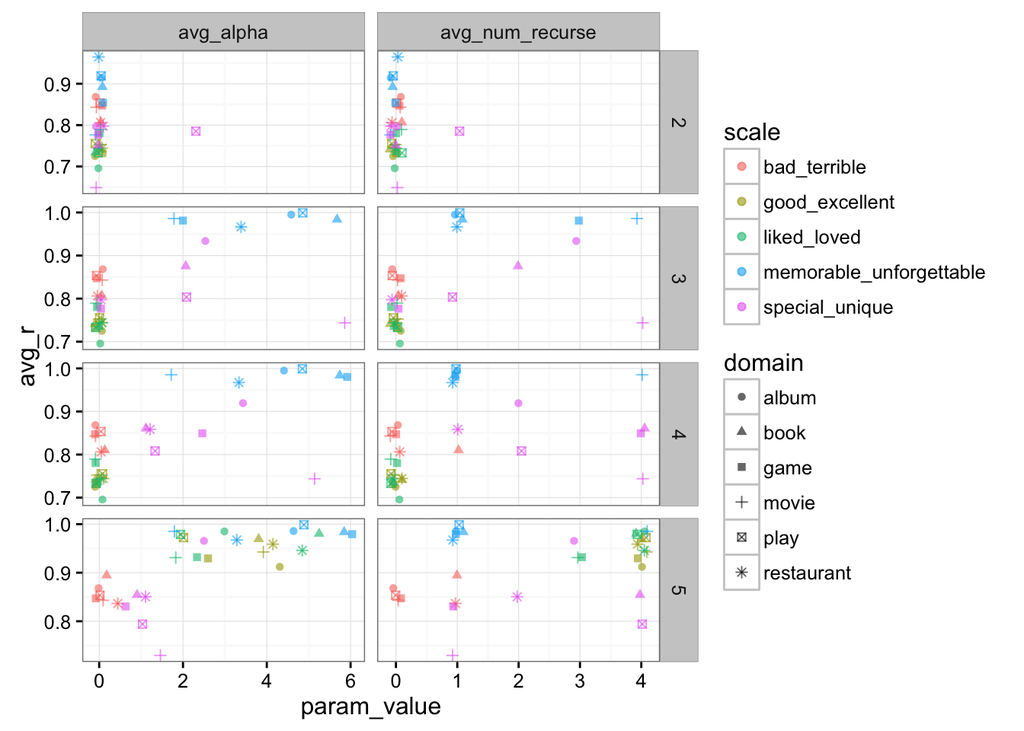

```r
# d_best_models[compare_indices,] %>%
#   group_by(model, scale, domain) %>%
#   summarise(avg_num_recurse=mean(depth),
#             avg_alpha=mean(alpha),
#             avg_r=cor(preds, prags)) %>%
#   gather(param_type, param_value, c(avg_num_recurse, avg_alpha)) %>%
#   ggplot(aes(x=avg_r, y=param_value, col=as.factor(param_type))) +
#     geom_point(alpha=0.6) +
#     facet_wrap(~model)
#
# d_best_models[compare_indices,] %>%
#   group_by(model, scale, domain) %>%
#   summarise(avg_num_recurse=mean(depth),
#             avg_alpha=mean(alpha),
#             avg_r=cor(preds, prags)) %>%
#   gather(param_type, param_value, c(avg_num_recurse, avg_alpha, model)) %>%
#   ggplot(aes(x=param_value, y=avg_r, col=scale, shape=domain)) +
#     geom_jitter(width = 0.25, alpha=0.6) +
#     facet_wrap(~param_type, scales="free")


d_best_models[compare_indices,] %>%
  group_by(model, scale, domain) %>%
  summarise(avg_num_recurse=mean(depth),
            avg_alpha=mean(alpha),
            avg_r=cor(preds, prags)) %>%
  gather(param_type, param_value, c(avg_num_recurse, avg_alpha)) %>%
  ggplot(aes(x=param_value, y=avg_r, col=scale, shape=domain)) +
    geom_jitter(width = 0.25, alpha=0.6) +
    facet_grid(model~param_type, scales="free") +
    theme_bw()
```

I think this is a visual that gets at the story a little – we can see the increase impact of `alpha` and `depth` as we include more alternatives. Avg correlation (y-axis) increases while the parameter settings do as well (x-axis). The spreading off the y-axis is indicates that the model is doing work over and above the literal semantics.

```r
d_best_models[compare_indices,] %>%
  group_by(model) %>%
  summarise(avg_num_recurse=mean(depth),
            avg_alpha=mean(alpha),
            avg_r=cor(preds, prags)) %>%
  knitr::kable()
```

| model | avg_num_recurse | avg_alpha | avg_r |
| --- | --- | --- | --- |
| 2 | 0.0333333 | 0.080000 | 0.7866941 |
| 3 | 0.7000000 | 1.146667 | 0.8131786 |
| 4 | 0.9000000 | 1.363333 | 0.8117845 |
| 5 | 2.4000000 | 2.510000 | 0.9030839 |

Scale specific `domain`

```r
d_best_models[compare_indices,] %>%
  group_by(model, scale) %>%
  summarise(avg_num_recurse=mean(depth),
            avg_alpha=mean(alpha),
            avg_r=cor(preds, prags)) %>%
  arrange(scale, model) %>%
  knitr::kable()
```

| model | scale | avg_num_recurse | avg_alpha | avg_r |
| --- | --- | --- | --- | --- |
| 2 | bad_terrible | 0.0000000 | 0.0000000 | 0.8379428 |
| 3 | bad_terrible | 0.0000000 | 0.0000000 | 0.8379428 |
| 4 | bad_terrible | 0.1666667 | 0.0333333 | 0.8346944 |
| 5 | bad_terrible | 0.3333333 | 0.1000000 | 0.8454589 |
| 2 | good_excellent | 0.0000000 | 0.0000000 | 0.7412707 |
| 3 | good_excellent | 0.0000000 | 0.0000000 | 0.7412707 |
| 4 | good_excellent | 0.0000000 | 0.0000000 | 0.7412707 |
| 5 | good_excellent | 4.0000000 | 3.5333333 | 0.9470518 |
| 2 | liked_loved | 0.0000000 | 0.0000000 | 0.7416171 |
| 3 | liked_loved | 0.0000000 | 0.0000000 | 0.7416171 |
| 4 | liked_loved | 0.0000000 | 0.0000000 | 0.7416171 |
| 5 | liked_loved | 3.6666667 | 3.2166667 | 0.9575048 |
| 2 | memorable_unforgettable | 0.0000000 | 0.0000000 | 0.8868590 |
| 3 | memorable_unforgettable | 1.8333333 | 3.6666667 | 0.9838803 |
| 4 | memorable_unforgettable | 1.5000000 | 4.3166667 | 0.9819550 |
| 5 | memorable_unforgettable | 1.5000000 | 4.4000000 | 0.9809295 |
| 2 | special_unique | 0.1666667 | 0.4000000 | 0.7577468 |
| 3 | special_unique | 1.6666667 | 2.0666667 | 0.8176659 |
| 4 | special_unique | 2.8333333 | 2.4666667 | 0.8327265 |
| 5 | special_unique | 2.5000000 | 1.3000000 | 0.8358455 |

Overall story:

— If people are reasoning about one another having a rich set of alternatives is beneficial (not just entailment alts).

– Model preds are sensitive to differences in `scale` and `domain` (we get best overall performance when we fit at these levels).

– If you don’t have those alternatives available, you might as well stick with the literal semantics (which will get you pretty far).

– Is this consistent with a developmental account (Rose’s paper)?

- i.e. inference requires both the ability to reason about others (theory of mind???).
- as well as acquisition of conventionalized alternatives sets (look at wordbank ages for quantifiers and scalar adjectives)
- how do depth and alpha really trade off? what is depth really getting at?

Do we see this with our cogsci data?

```r
peloquinFrank_2Alts %>%
  group_by(scale) %>%
  summarise(r=cor(speaker.p, e11)) %>%
  knitr::kable()
```

| scale | r |
| --- | --- |
| good_excellent | 0.7793686 |
| liked_loved | 0.8122940 |
| memorable_unforgettable | 0.8776487 |
| palatable_delicious | 0.7141740 |
| some_all | 0.6044819 |

We also see (fairly) good fit between literal semantics with cogsci L0 data nd pragmatic judgments.

## Tuned RSA

– `depth=fit`, `alpha=fit` 2-alt vs 3-alt vs 4-alt vs 5-alt models

– Standard theory predicts that listeners need only consider entailment alternatives in order to generate the implicature (2-alt model)

– Test: do we see better model fit (correlation) by adding more alternatives?

```r
# rsa.tuneDepthAlpha()
```

## Secondary analysis

– Any particular domains are scalar families harder for RSA to fit? Why?

```r
# ggplot()
```